# (Exploring Ford's GoBike dataset)

## by (Abdelrahman Talaat)

## Investigation Overview

> To show few interesting trends i found in this dataset

## Dataset Overview

> Data contains a lot of information about the rides but most of the information is redundant and hard to use like coordinates of the start and the end of the ride can be used to calculate distance like this Δψ = ln( tan(π/4 + φ2/2) / tan(π/4 + φ1/2) ), and I just couldnt understand the formula

> So I made use of duration time of the ride, user type(customer/subscribes), gender , bike shares for all trip or not? and finally member birthyear

## (Visualization 1)

> most of bike rides' duration spans from 100 seconds to 3000 seconds (notice that the xscale is logerthmic)

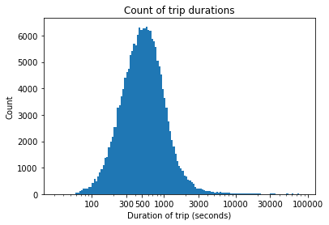

## (Visualization 2)

> Customers use the service for more duration than subscribes and female users use it the most on both user types, but people with other genders tend to use it almost as much as female users when they are subscribes and the lowest as customers

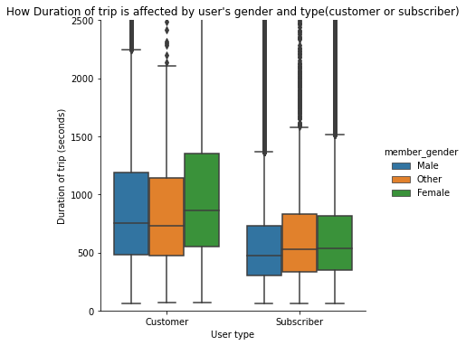

## (Visualization 3)

> it looks like most of the users are from the younger generation and users who use the app (notice that the scale is logerithmic)

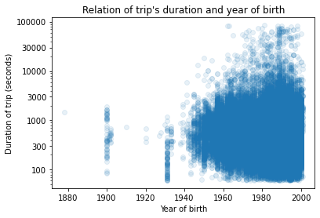

## (Visualization 4)

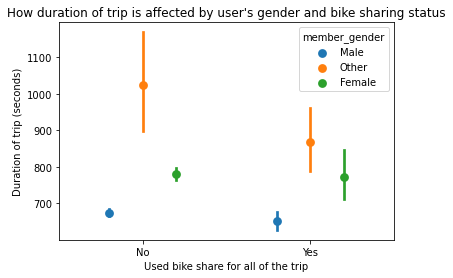